# Infant Mortality EDA

Andy

2026-02-25

## 1. Load Libraries & Data

```r
library(tidyverse)

# Read the data — note: NYS 2020 has a comma in the Total field, so we
# read it as character first and clean it manually.
raw <- read_csv(
  here::here("data", "Infant Mortality Data.csv"),
  col_types = cols(Total = col_character())
)

df <- raw %>%
  mutate(
    Total = as.numeric(gsub(",", "", Total)),
    Rate  = as.numeric(Rate),
    Age   = factor(Age, levels = c("Infant", "Neonatal"))
  )

glimpse(df)
```

```
## Rows: 90
## Columns: 7
## $ Location <chr> "Geneva", "Ontario", "NYS", "Geneva", "Ontario", "NYS", "Gene…
## $ Source   <chr> "https://www.health.ny.gov/statistics/vital_statistics/2010/t…
## $ Year     <dbl> 2010, 2010, 2010, 2011, 2011, 2011, 2012, 2012, 2012, 2013, 2…
## $ Total    <dbl> 149, 1036, 242914, 149, 1020, 239736, 159, 1045, 239224, 167,…
## $ Deaths   <dbl> 2, 7, 1227, 0, 5, 1202, 1, 5, 1191, 1, 3, 1144, 0, 5, 1090, 1…
## $ Rate     <dbl> 13.4, 6.8, 5.1, 0.0, 4.9, 5.0, 6.3, 4.8, 5.0, 6.0, 2.9, 4.9, …
## $ Age      <fct> Infant, Infant, Infant, Infant, Infant, Infant, Infant, Infan…
```

## 2. Dataset Overview

```r
summary(df)
```

```
##    Location            Source               Year          Total
##  Length:90          Length:90          Min.   :2007   Min.   :   121
##  Class :character   Class :character   1st Qu.:2010   1st Qu.:   167
##  Mode  :character   Mode  :character   Median :2014   Median :  1028
##                                        Mean   :2014   Mean   : 78268
##                                        3rd Qu.:2018   3rd Qu.:225162
##                                        Max.   :2021   Max.   :252662
##      Deaths            Rate              Age
##  Min.   :   0.0   Min.   : 0.000   Infant  :45
##  1st Qu.:   1.0   1st Qu.: 2.925   Neonatal:45
##  Median :   5.0   Median : 4.250
##  Mean   : 312.4   Mean   : 4.424
##  3rd Qu.: 743.8   3rd Qu.: 5.725
##  Max.   :1382.0   Max.   :16.500
```

The dataset covers **three locations** — Geneva (city), Ontario (county), and NYS (New York State statewide) — across **2007–2021**, for two mortality categories:

- **Infant**: death within the first year of life
- **Neonatal**: death within the first 28 days of life

The rate is expressed as **deaths per 1,000 live births**.

## 3. Data Quality Check

Before exploring trends, it’s worth flagging a few things worth thinking about.

### 3a. Zero-death years

Geneva is a small city. In many years, there were simply no infant deaths recorded, which produces a rate of 0. This is not necessarily good news — it reflects **small sample size**, which makes rates highly volatile.

```r
df %>%
  filter(Deaths == 0) %>%
  select(Location, Year, Age, Total, Deaths, Rate) %>%
  arrange(Location, Age, Year)
```

```
## # A tibble: 14 × 6
##    Location  Year Age      Total Deaths  Rate
##    <chr>    <dbl> <fct>    <dbl>  <dbl> <dbl>
##  1 Geneva    2011 Infant     149      0     0
##  2 Geneva    2014 Infant     164      0     0
##  3 Geneva    2016 Infant     149      0     0
##  4 Geneva    2017 Infant     169      0     0
##  5 Geneva    2018 Infant     137      0     0
##  6 Geneva    2020 Infant     133      0     0
##  7 Geneva    2021 Infant     135      0     0
##  8 Geneva    2011 Neonatal   149      0     0
##  9 Geneva    2014 Neonatal   164      0     0
## 10 Geneva    2016 Neonatal   149      0     0
## 11 Geneva    2017 Neonatal   169      0     0
## 12 Geneva    2018 Neonatal   137      0     0
## 13 Geneva    2020 Neonatal   133      0     0
## 14 Geneva    2021 Neonatal   135      0     0
```

### 3b. Potential data anomaly — Ontario 2021 Neonatal

```r
df %>%
  filter(Location == "Ontario", Age == "Neonatal", Year == 2021)
```

```
## # A tibble: 1 × 7
##   Location Source                                  Year Total Deaths  Rate Age
##   <chr>    <chr>                                  <dbl> <dbl>  <dbl> <dbl> <fct>
## 1 Ontario  https://www.health.ny.gov/statistics/…  2021   979     63   6.1 Neon…
```

Ontario 2021 Neonatal shows **63 deaths** from 979 births. Back-calculating: 63/979 × 1000 ≈ 64.3, but the Rate column says 6.1. This is worth investigating — it looks like the Deaths value may be a typo (63 instead of 6). Keep this in mind when reading Neonatal charts.

### 3c. Declining total births over time

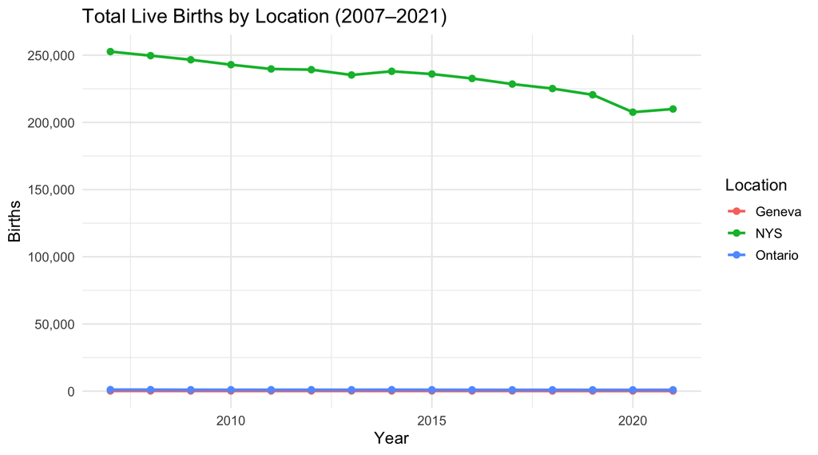

```r
df %>%
  filter(Age == "Infant") %>%           # avoid double-counting (same births for both types)
  ggplot(aes(x = Year, y = Total, color = Location)) +
  geom_line(linewidth = 1) +
  geom_point(size = 2) +
  scale_y_continuous(labels = scales::comma) +
  labs(
    title   = "Total Live Births by Location (2007–2021)",
    y       = "Births",
    x       = "Year",
    color   = "Location"
  ) +
  theme_minimal(base_size = 13)
```

Births have been declining across all three locations over the period — a useful backdrop for interpreting death counts vs. rates.

## 4. Mortality Rate Trends Over Time

### 4a. Infant mortality rate

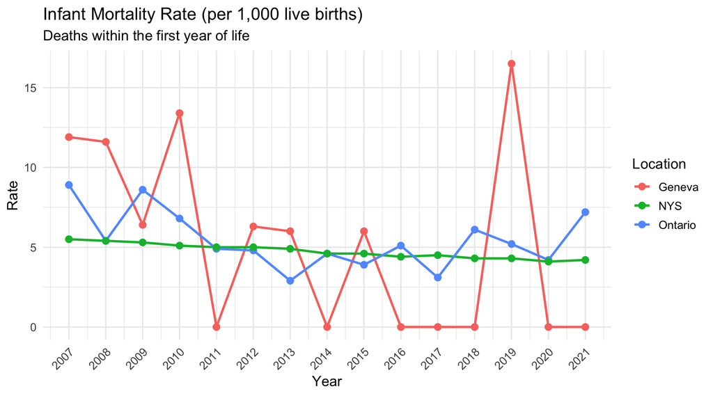

```r
df %>%
  filter(Age == "Infant") %>%
  ggplot(aes(x = Year, y = Rate, color = Location)) +
  geom_line(linewidth = 1) +
  geom_point(size = 2.5) +
  scale_x_continuous(breaks = 2007:2021) +
  labs(
    title    = "Infant Mortality Rate (per 1,000 live births)",
    subtitle = "Deaths within the first year of life",
    y        = "Rate",
    x        = "Year",
    color    = "Location"
  ) +
  theme_minimal(base_size = 13) +
  theme(axis.text.x = element_text(angle = 45, hjust = 1))
```

Geneva’s rate is extremely erratic — swinging from 0 to 16.5 (2019) — which reflects its small birth count (~120–170/year). A single death changes the rate dramatically. Ontario and NYS track more closely together.

### 4b. Neonatal mortality rate

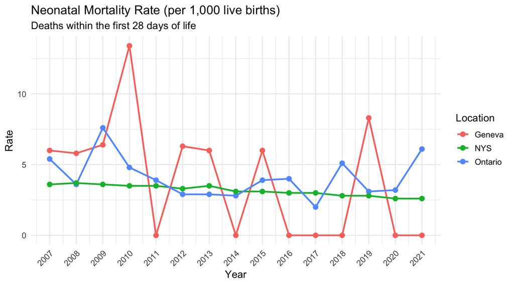

```r
df %>%
  filter(Age == "Neonatal") %>%
  ggplot(aes(x = Year, y = Rate, color = Location)) +
  geom_line(linewidth = 1) +
  geom_point(size = 2.5) +
  scale_x_continuous(breaks = 2007:2021) +
  labs(
    title    = "Neonatal Mortality Rate (per 1,000 live births)",
    subtitle = "Deaths within the first 28 days of life",
    y        = "Rate",
    x        = "Year",
    color    = "Location"
  ) +
  theme_minimal(base_size = 13) +
  theme(axis.text.x = element_text(angle = 45, hjust = 1))
```

### 4c. Both types side by side (faceted)

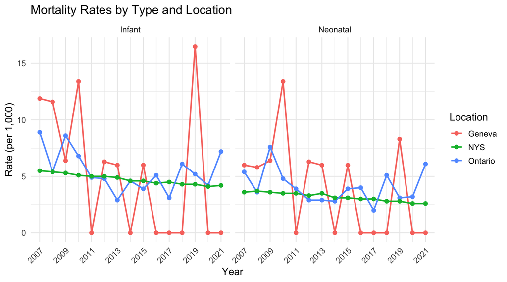

```r
df %>%
  ggplot(aes(x = Year, y = Rate, color = Location)) +
  geom_line(linewidth = 0.9) +
  geom_point(size = 2) +
  facet_wrap(~Age, ncol = 2) +
  scale_x_continuous(breaks = seq(2007, 2021, 2)) +
  labs(
    title  = "Mortality Rates by Type and Location",
    y      = "Rate (per 1,000)",
    x      = "Year",
    color  = "Location"
  ) +
  theme_minimal(base_size = 13) +
  theme(axis.text.x = element_text(angle = 45, hjust = 1))
```

## 5. Infant vs. Neonatal: How Much Happens After Day 28?

Neonatal deaths (first 28 days) are a subset of infant deaths (first year). The **post-neonatal** deaths — those occurring between day 29 and the end of year 1 — can be derived by subtraction.

```r
# Reshape to compute post-neonatal deaths
pn <- df %>%
  select(Location, Year, Age, Deaths, Rate) %>%
  pivot_wider(names_from = Age, values_from = c(Deaths, Rate)) %>%
  mutate(
    Deaths_PostNeonatal = Deaths_Infant - Deaths_Neonatal,
    Pct_Neonatal        = round(Deaths_Neonatal / Deaths_Infant * 100, 1)
  ) %>%
  filter(!is.na(Deaths_Infant), Deaths_Infant > 0)

pn %>%
  select(Location, Year, Deaths_Infant, Deaths_Neonatal, Deaths_PostNeonatal, Pct_Neonatal) %>%
  arrange(Location, Year)
```

```
## # A tibble: 38 × 6
##    Location  Year Deaths_Infant Deaths_Neonatal Deaths_PostNeonatal Pct_Neonatal
##    <chr>    <dbl>         <dbl>           <dbl>               <dbl>        <dbl>
##  1 Geneva    2007             2               1                   1         50
##  2 Geneva    2008             2               1                   1         50
##  3 Geneva    2009             1               1                   0        100
##  4 Geneva    2010             2               2                   0        100
##  5 Geneva    2012             1               1                   0        100
##  6 Geneva    2013             1               1                   0        100
##  7 Geneva    2015             1               1                   0        100
##  8 Geneva    2019             2               1                   1         50
##  9 NYS       2007          1382             910                 472         65.8
## 10 NYS       2008          1359             919                 440         67.6
## # ℹ 28 more rows
```

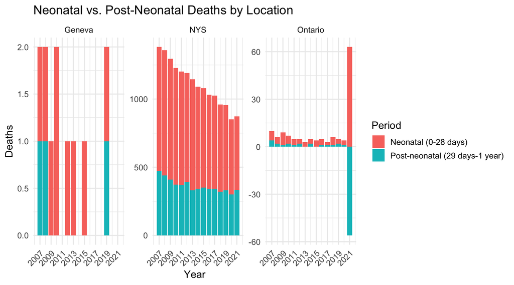

```r
pn %>%
  select(Location, Year, Deaths_Neonatal, Deaths_PostNeonatal) %>%
  pivot_longer(cols = starts_with("Deaths_"), names_to = "Period", values_to = "Deaths") %>%
  mutate(Period = recode(Period,
    "Deaths_Neonatal"     = "Neonatal (0-28 days)",
    "Deaths_PostNeonatal" = "Post-neonatal (29 days-1 year)"
  )) %>%
  ggplot(aes(x = Year, y = Deaths, fill = Period)) +
  geom_col() +
  facet_wrap(~Location, scales = "free_y") +
  scale_x_continuous(breaks = seq(2007, 2021, 2)) +
  labs(
    title  = "Neonatal vs. Post-Neonatal Deaths by Location",
    y      = "Deaths",
    x      = "Year",
    fill   = "Period"
  ) +
  theme_minimal(base_size = 13) +
  theme(axis.text.x = element_text(angle = 45, hjust = 1))
```

## 6. Geneva Closer Look

Geneva’s small population makes aggregate rates noisy, but the raw death counts are interpretable. Every death matters here.

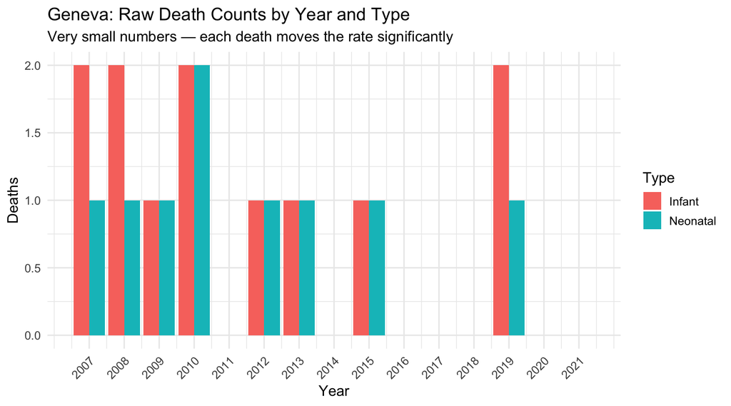

```r
df %>%
  filter(Location == "Geneva") %>%
  ggplot(aes(x = Year, y = Deaths, fill = Age)) +
  geom_col(position = "dodge") +
  scale_x_continuous(breaks = 2007:2021) +
  labs(
    title    = "Geneva: Raw Death Counts by Year and Type",
    subtitle = "Very small numbers — each death moves the rate significantly",
    y        = "Deaths",
    x        = "Year",
    fill     = "Type"
  ) +
  theme_minimal(base_size = 13) +
  theme(axis.text.x = element_text(angle = 45, hjust = 1))
```

```r
# Show how a single birth/death changes Geneva's rate drastically
df %>%
  filter(Location == "Geneva", Age == "Infant") %>%
  mutate(Rate_Check = round(Deaths / Total * 1000, 1)) %>%
  select(Year, Total, Deaths, Rate, Rate_Check)
```

```
## # A tibble: 15 × 5
##     Year Total Deaths  Rate Rate_Check
##    <dbl> <dbl>  <dbl> <dbl>      <dbl>
##  1  2010   149      2  13.4       13.4
##  2  2011   149      0   0          0
##  3  2012   159      1   6.3        6.3
##  4  2013   167      1   6          6
##  5  2014   164      0   0          0
##  6  2015   167      1   6          6
##  7  2016   149      0   0          0
##  8  2009   156      1   6.4        6.4
##  9  2008   173      2  11.6       11.6
## 10  2007   168      2  11.9       11.9
## 11  2017   169      0   0          0
## 12  2018   137      0   0          0
## 13  2019   121      2  16.5       16.5
## 14  2020   133      0   0          0
## 15  2021   135      0   0          0
```

## 7. Summary Statistics by Location

```r
df %>%
  filter(Rate > 0) %>%             # exclude structural zeros (no deaths)
  group_by(Location, Age) %>%
  summarise(
    Mean_Rate   = round(mean(Rate), 2),
    Median_Rate = round(median(Rate), 2),
    Min_Rate    = min(Rate),
    Max_Rate    = max(Rate),
    SD_Rate     = round(sd(Rate), 2),
    .groups     = "drop"
  ) %>%
  arrange(Age, Location)
```

```
## # A tibble: 6 × 7
##   Location Age      Mean_Rate Median_Rate Min_Rate Max_Rate SD_Rate
##   <chr>    <fct>        <dbl>       <dbl>    <dbl>    <dbl>   <dbl>
## 1 Geneva   Infant        9.76        9         6       16.5    4.11
## 2 NYS      Infant        4.75        4.6       4.1      5.5    0.46
## 3 Ontario  Infant        5.45        5.1       2.9      8.9    1.79
## 4 Geneva   Neonatal      7.28        6.15      5.8     13.4    2.6
## 5 NYS      Neonatal      3.18        3.1       2.6      3.7    0.38
## 6 Ontario  Neonatal      4.09        3.9       2        7.6    1.48
```

## 8. Key Takeaways

1. **Geneva’s rates are unreliable as a standalone metric** — with ~150 births/year, one or two deaths create huge rate swings. Any comparison to Ontario or NYS should be interpreted cautiously.
2. **NYS shows a consistent downward trend** in both infant and neonatal rates from 2007 to 2020, which is encouraging. Ontario roughly mirrors this.
3. **Neonatal deaths make up the majority of infant deaths** at all three locations, suggesting that interventions targeting the first 28 days of life would have the greatest impact.
4. **The Ontario 2021 Neonatal record (63 deaths)** appears to be a data entry error and should be verified against the source before any conclusions are drawn from it.
5. **Total births are declining** across all locations. This is important context — even if death counts stay flat, the rate can rise, which may be misleading without this backdrop.